# 🧠 Media Bias Classifier

### 👨‍🎓 Curriculum Learning

Instead of feeding the model data randomly, curriculum learning starts with easier examples first, and moves on to harder ones later, because the model starts off being "stupid".

##### 🔎 Line by line breakdown

`train_data = [(titles[i], df["content"].iloc[i], labels[i]) for i in train_index]` takes the training indices from the split. For each index it grabs the:

- title
- content
- label

It creates a list of tuples like: `[("Why something is great", "Something is amazing, because...", 0), (...), ...]`

`train_titles, train_contents, train_labels = zip(*train_data)` creates separate lists for all the titles, contents, and labels.

`train_texts_full = [f"{title} {content}" for title, content in zip(train_titles, train_contents)]` combines the title and content into one text.

`tfidf_scores = compute_tfidf_scores(train_texts_full)` High TF-IDF score → article is unique, has rare words. Low score → article is generic, uses common words.

`train_data_with_scores = list(zip(train_titles, train_contents, train_labels, tfidf_scores))` now each sample has a score.

`train_data_with_scores.sort(key=lambda x: x[3], reverse=True)` sorts the data using the fourth element of the tuple, which is the **tfidf_score**. `reverse=True` determines that the order should be descending.

`train_titles, train_contents, train_labels, _ = zip(*train_data_with_scores)` now the data is sorted using the tfidf scores, so they can be ignored and the data can now be used for curriculum learning.

```python
from sklearn.metrics import classification_report
from transformers import AutoTokenizer, DebertaV2ForSequenceClassification, Trainer, TrainingArguments
from sklearn.model_selection import StratifiedKFold as skf
from collections import Counter
import torch
import numpy as np

tokenizer = AutoTokenizer.from_pretrained("microsoft/deberta-v3-base", num_labels=3)

class NewsDataset(torch.utils.data.Dataset):
    def __init__(self, encodings, labels):
        self.encodings = encodings
        self.labels = labels

    def __len__(self):
        return len(self.labels)

    def __getitem__(self, idx):
        item = {key: val[idx].clone().detach() for key, val in self.encodings.items()}
        item['labels'] = torch.tensor(self.labels[idx])
        return item

class CurriculumTrainer(Trainer):
    def get_train_dataloader(self):
        # Disable shuffling for curriculum learning
        return torch.utils.data.DataLoader(
            self.train_dataset,
            batch_size=self.args.train_batch_size,
            shuffle=False,
            collate_fn=self.data_collator,
            drop_last=False,
        )

titles = df["cleaned_title"].tolist()
labels = df["label_id"].tolist()
accuracies = []  # Initialize accuracies list for storing fold results

stratified_kfold = skf(n_splits=3, shuffle=True, random_state=42)

model = DebertaV2ForSequenceClassification.from_pretrained("microsoft/deberta-v3-base", num_labels=3)

for fold, (train_index, val_index) in enumerate(stratified_kfold.split(titles, labels)):
    print(f"\n===== Fold {fold + 1} =====")

    # STEP 1: Grab training data using the indices from StratifiedKFold
    train_data = [
        (titles[i], df["cleaned_content"].iloc[i], labels[i]) for i in train_index
    ]

    # STEP 2: Unpack (unzip) train_data into individual lists
    train_titles, train_contents, train_labels = zip(*train_data)

    # STEP 3: Combine title and content for each sample
    train_texts_full = [f"{title} {content}" for title, content in zip(train_titles, train_contents)]

    # STEP 4: Compute TF-IDF scores for all the combined texts
    tfidf_scores = compute_tfidf_scores(train_texts_full)

    # STEP 5: Attach the scores to the data for sorting
    train_data_with_scores = list(zip(train_titles, train_contents, train_labels, tfidf_scores))

    # STEP 6: Sort the data — lowest TF-IDF (most ambiguous) comes last in curriculum
    train_data_with_scores.sort(key=lambda x: x[3], reverse=True)

    # STEP 7: Unpack the sorted data (ignore the scores now)
    train_titles, train_contents, train_labels, _ = zip(*train_data_with_scores)

    val_titles = [titles[i] for i in val_index]
    val_contents = [df["cleaned_content"].iloc[i] for i in val_index]
    val_labels = [labels[i] for i in val_index]

    print(f"Training label distribution: {Counter(train_labels)}")
    print(f"Validation label distribution: {Counter(val_labels)}")

    train_texts = [truncate_for_model(t, c) for t, c in zip(train_titles, train_contents)]
    val_texts = [truncate_for_model(t, c) for t, c in zip(val_titles, val_contents)]

    train_encodings = tokenizer(train_texts, max_length=384, truncation=True, padding=True, return_tensors='pt')
    val_encodings = tokenizer(val_texts, max_length=384, truncation=True, padding=True, return_tensors='pt')

    train_dataset = NewsDataset(train_encodings, train_labels)
    val_dataset = NewsDataset(val_encodings, val_labels)

    training_args = TrainingArguments(
        output_dir=f"./results_fold_{fold}",
        num_train_epochs=5,
        per_device_train_batch_size=4,
        per_device_eval_batch_size=4,
        warmup_steps=100,
        weight_decay=0.1,
        logging_dir=None,
        logging_steps=999999,
        eval_strategy="epoch",
        save_strategy="epoch",
        load_best_model_at_end=True,
        metric_for_best_model="eval_accuracy",
        save_total_limit=1,
        report_to="none",
        learning_rate=3e-5,
        fp16=True,
        lr_scheduler_type='cosine',
        gradient_accumulation_steps=2
    )

    def compute_accuracy(pred):
        labels = pred.label_ids
        preds = np.argmax(pred.predictions, axis=1)
        accuracy = (preds == labels).mean()
        return {"accuracy": accuracy}

    trainer = CurriculumTrainer(
        model=model,
        args=training_args,
        train_dataset=train_dataset,
        eval_dataset=val_dataset,
        compute_metrics=compute_accuracy
    )

    trainer.train()

    eval_result = trainer.evaluate()
    trainer.save_model(f"saved_models/fold_{fold}")
    tokenizer.save_pretrained(f"saved_models/fold_{fold}")
    print(f"Fold {fold + 1} Accuracy: {eval_result['eval_accuracy']:.4f}")
    accuracies.append(eval_result['eval_accuracy'])

    # Generate predictions and classification report
    predictions = trainer.predict(val_dataset)
    pred_labels = np.argmax(predictions.predictions, axis=1)
    print("\nClassification Report:")
    print(classification_report(val_labels, pred_labels))

print("\n===== Cross-Validation Complete =====")
print(f"Mean Accuracy: {np.mean(accuracies):.4f}")
```

```
===== Fold 1 =====
Training label distribution: Counter({2: 9156, 1: 8670, 0: 7210})
Validation label distribution: Counter({2: 4578, 1: 4335, 0: 3605})
```

[15645/15645 1:34:26, Epoch 4/5]

| Epoch | Training Loss | Validation Loss | Accuracy |
| --- | --- | --- | --- |
| 1 | No log | 0.553218 | 0.778719 |
| 2 | No log | 0.537667 | 0.834319 |
| 3 | No log | 0.565283 | 0.854689 |
| 4 | No log | 0.629572 | 0.871146 |

```
Fold 1 Accuracy: 0.8711

Classification Report:
              precision    recall  f1-score   support

           0       0.86      0.85      0.85      3605
           1       0.87      0.87      0.87      4335
           2       0.89      0.89      0.89      4578

    accuracy                           0.87     12518
   macro avg       0.87      0.87      0.87     12518
weighted avg       0.87      0.87      0.87     12518


===== Fold 2 =====
Training label distribution: Counter({2: 9156, 1: 8670, 0: 7210})
Validation label distribution: Counter({2: 4578, 1: 4335, 0: 3605})
```

[15645/15645 1:30:46, Epoch 4/5]

| Epoch | Training Loss | Validation Loss | Accuracy |
| --- | --- | --- | --- |
| 1 | No log | 0.286108 | 0.902540 |
| 2 | No log | 0.304475 | 0.906535 |
| 3 | No log | 0.335786 | 0.921473 |
| 4 | No log | 0.345463 | 0.934414 |

```
Fold 2 Accuracy: 0.9344

Classification Report:
              precision    recall  f1-score   support

           0       0.91      0.92      0.92      3605
           1       0.93      0.94      0.94      4335
           2       0.95      0.94      0.95      4578

    accuracy                           0.93     12518
   macro avg       0.93      0.93      0.93     12518
weighted avg       0.93      0.93      0.93     12518


===== Fold 3 =====
Training label distribution: Counter({2: 9156, 1: 8670, 0: 7210})
Validation label distribution: Counter({2: 4578, 1: 4335, 0: 3605})
```

[15645/15645 1:30:46, Epoch 4/5]

[output not shown]

```
Fold 3 Accuracy: 0.9764

Classification Report:
              precision    recall  f1-score   support

           0       0.97      0.97      0.97      3605
           1       0.97      0.98      0.97      4335
           2       0.98      0.98      0.98      4578

    accuracy                           0.98     12518
   macro avg       0.98      0.98      0.98     12518
weighted avg       0.98      0.98      0.98     12518


===== Cross-Validation Complete =====
Mean Accuracy: 0.9273
```

# 🔎 Evaluation

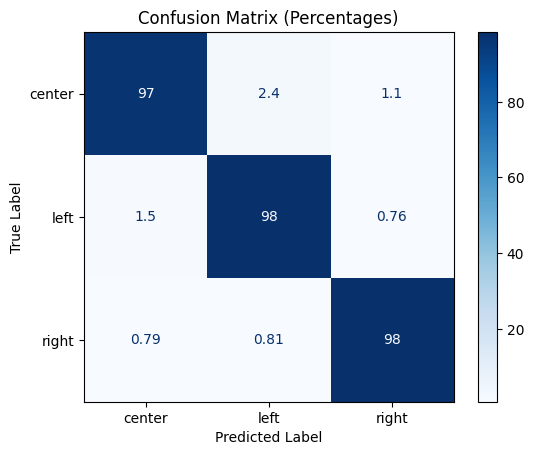

```python
from sklearn.metrics import ConfusionMatrixDisplay

# Generate the confusion matrix
cm = confusion_matrix(val_labels, pred_labels)

# Normalize the confusion matrix to show percentages
cm_percentage = cm.astype('float') / cm.sum(axis=1)[:, np.newaxis] * 100

# Display the confusion matrix with percentages
disp = ConfusionMatrixDisplay(confusion_matrix=cm_percentage, display_labels=label_encoder.classes_)
disp.plot(cmap=plt.cm.Blues)
plt.title("Confusion Matrix (Percentages)")
plt.xlabel("Predicted Label")
plt.ylabel("True Label")
plt.show()
```

```python
# Load the best model
model = DebertaV2ForSequenceClassification.from_pretrained("../models/DeBERTa_97")

# Just use content for validation now
content_only_val_texts = val_contents  # Don't prepend title

# Tokenize only content
content_only_val_encodings = tokenizer(content_only_val_texts, max_length=384, truncation=True, padding=True, return_tensors='pt')

# Wrap in Dataset
content_only_val_dataset = NewsDataset(content_only_val_encodings, val_labels)

# Put model in eval mode
model.eval()

# Move to the same device as used in training
device = torch.device("cuda" if torch.cuda.is_available() else "cpu")
model.to(device)

# Make predictions
with torch.no_grad():
    all_logits = []
    for i in range(0, len(content_only_val_dataset), 16):  # Use reasonable batch size
        batch = content_only_val_dataset[i:i+16]
        input_ids = batch['input_ids'].to(device)
        attention_mask = batch['attention_mask'].to(device)

        outputs = model(input_ids=input_ids, attention_mask=attention_mask)
        logits = outputs.logits
        all_logits.append(logits.cpu())

    all_logits = torch.cat(all_logits)
    preds = torch.argmax(all_logits, dim=1).numpy()

# Evaluate
print("Classification Report (Content Only):")
print(classification_report(val_labels, preds))
print("Accuracy (Content Only):", accuracy_score(val_labels, preds))
```

```
Classification Report (Content Only):
              precision    recall  f1-score   support

           0       0.86      0.89      0.87      3605
           1       0.91      0.81      0.86      4335
           2       0.84      0.90      0.87      4578

    accuracy                           0.87     12518
   macro avg       0.87      0.87      0.87     12518
weighted avg       0.87      0.87      0.87     12518

Accuracy (Content Only): 0.8660329126058476
```